# TFLink use case 3

Investigating the binding sites of the EGR1 transcription factor

# 1 The aim of this use case

Here we investigate the binding sites of the **EGR1** transcription factor. After converting the [TFLink](https://tflink.net/) binding site table to **BED** and [**BAM**](https://en.wikipedia.org/wiki/Binary_Alignment_Map) files, we calculate the “coverage” to reveal the strength of evidence (number of supporting experiments) for each binding site. Then we plot the binding sites on the human chromosomes, indicating the number of supporting evidences each binding site has. Finally, we investigate specific binding sites using the [IGV genome viewer](https://software.broadinstitute.org/software/igv/) tool.

# 2 The input data

Let’s download the [*binding site table* of human **EGR1** transcription factor](https://tflink.net/protein/p18146/) from the [TFLink](https://tflink.net/) website, and read it in to `R` with the `read_tsv` command of the `tidyverse` package.

```r
library(tidyverse)
EGR1_BS_tab <- read_tsv("TFLink_P18146_TFBS_annot_v1.0.tsv")
```

Let’s see the first few rows of the binding site table.

```r
EGR1_BS_tab %>%
  slice(1:5)
```

Head of the binding site table (continued below)

| TFLinkID | UniprotID.TF | Name.TF | Organism | Assembly | Chromosome | Start | End |
| --- | --- | --- | --- | --- | --- | --- | --- |
| TFLinkSS09532447 | P18146 | EGR1 | Homo sapiens | hg38 | chr14 | 59361534 | 59361673 |
| TFLinkSS09543853 | P18146 | EGR1 | Homo sapiens | hg38 | chr14 | 37596110 | 37596200 |
| TFLinkSS09543856 | P18146 | EGR1 | Homo sapiens | hg38 | chr14 | 96264096 | 96264186 |
| TFLinkSS09543857 | P18146 | EGR1 | Homo sapiens | hg38 | chr14 | 37594940 | 37595000 |
| TFLinkSS09543858 | P18146 | EGR1 | Homo sapiens | hg38 | chr14 | 37595930 | 37595990 |

Table continues below

| Strand | Genome.browser | Detection.method | PubmedID | Source.database |
| --- | --- | --- | --- | --- |
| + | https://genome.ucsc.edu/cgi-bin/hgTracks?db=hg38&position=chr14:59361534-59361673 | inferred by curator | 18971253 | ORegAnno |
| + | https://genome.ucsc.edu/cgi-bin/hgTracks?db=hg38&position=chr14:37596110-37596200 | inferred by curator | 18971253 | ORegAnno |
| + | https://genome.ucsc.edu/cgi-bin/hgTracks?db=hg38&position=chr14:96264096-96264186 | inferred by curator | 18971253 | ORegAnno |
| + | https://genome.ucsc.edu/cgi-bin/hgTracks?db=hg38&position=chr14:37594940-37595000 | inferred by curator | 18971253 | ORegAnno |
| + | https://genome.ucsc.edu/cgi-bin/hgTracks?db=hg38&position=chr14:37595930-37595990 | inferred by curator | 18971253 | ORegAnno |

| Small-scale.evidence | Number.of.TFBS.overlaps | TFBS.overlaps |
| --- | --- | --- |
| Yes | 0 | - |
| Yes | 0 | - |
| Yes | 0 | - |
| Yes | 0 | - |
| Yes | 0 | - |

Let’s check the number of binding sites of the **EGR1** transcription factor.

```r
EGR1_BS_tab %>%
  nrow()
```

[1] 156418

# 3 Converting the binding site table to BED and BAM files

Let’s check the names of the chromosomes used in the binding site table.

```r
EGR1_BS_tab %>%
  group_by(Chromosome) %>%
  group_keys() %>%
  pull()
```

chr1, chr10, chr11, chr12, chr13, chr14, chr14_GL000009v2_random, chr14_GL000225v1_random, chr15, chr16, chr17, chr18, chr19, chr2, chr2_KI270894v1_alt, chr20, chr21, chr22, chr22_KI270735v1_random, chr22_KI270879v1_alt, chr3, chr4, chr4_GL000008v2_random, chr5, chr6, chr7, chr7_KI270803v1_alt, chr8, chr8_KI270821v1_alt, chr9, chrM, chrUn_GL000219v1, chrUn_KI270442v1, chrUn_KI270742v1, chrX, chrY

## 3.1 Excluding non-canonical chromosomes and saving the BED files

If we want to check the “coverage” for the *canonical* human chromosomes only, we need to exclude all other contigs from the *EGR1_BS_tab* table.

```r
# Keeping rows where the name of the chromosome doesn't include "_", and
# excluding the mitochondrial chromosome (chrM) as well.

# Creating a singe BED file containing the data about the FORWARD and REVERSE
# strands.
EGR1_BS_tab %>%
  filter(!grepl(x = Chromosome, pattern = "_|M")) %>%
  mutate(Name = "EGR1", Score = 1000) %>%
  select(Chromosome, Start, End, Name, Score, Strand) %>%
  arrange(Chromosome, Start, End, Strand) %>%
  write_tsv("EGR1_BS.bed", col_names = FALSE)

# Creating a BED file containing the data about the FORWARD strand only.
EGR1_BS_tab %>%
  filter(!grepl(x = Chromosome, pattern = "_|M") & Strand == "+") %>%
  mutate(Name = "EGR1", Score = 1000) %>%
  select(Chromosome, Start, End, Name, Score, Strand) %>%
  arrange(Chromosome, Start, End, Strand) %>%
  write_tsv("EGR1_BS_forward.bed", col_names = FALSE)

# Creating a BED file containing the data about the REVERSE strand only.
EGR1_BS_tab %>%
  filter(!grepl(x = Chromosome, pattern = "_|M") & Strand == "-") %>%
  mutate(Name = "EGR1", Score = 1000) %>%
  select(Chromosome, Start, End, Name, Score, Strand) %>%
  arrange(Chromosome, Start, End, Strand) %>%
  write_tsv("EGR1_BS_reverse.bed", col_names = FALSE)
```

Let’s convert the **BED** file to **BAM** using the `bedtobam` command of the [bedtools](https://bedtools.readthedocs.io/en/latest/index.html) software package.

For this we need a text file, called: **chrom.sizes** containing the name and the size (in base pairs) of the chromosomes. We can download this for the human genome version *hg38* from [here](https://hgdownload.soe.ucsc.edu/goldenPath/hg38/bigZips/hg38.chrom.sizes).

```r
chrom_sizes_tab <- read_tsv(
  "https://hgdownload.soe.ucsc.edu/goldenPath/hg38/bigZips/hg38.chrom.sizes",
  col_names = c("Chromosome", "Size"))
chrom_sizes_tab %>%
  write_tsv("chrom.sizes", col_names = FALSE)
```

Now we can run the `bedToBam` command in the **terminal** to create the **BAM** files.

```bash
# Forward strand BAM
$ bedToBam -i EGR1_BS_forward.bed -g chrom.sizes > EGR1_BS_forward.bam
# Reverse strand BAM
$ bedToBam -i EGR1_BS_reverse.bed -g chrom.sizes > EGR1_BS_reverse.bam
```

# 4 Calculating and investigating the “coverage”

Let’s calculate the number of evidences each binding site has using the samtools software.

```bash
# Forward strand BAM
$ samtools depth EGR1_BS_forward.bam > EGR1_BS_forward.coverage
# Reverse strand BAM
$ samtools depth EGR1_BS_reverse.bam > EGR1_BS_reverse.coverage
```

## 4.1 Reading in the “coverage” files to `R`.

Now we use the `fread` function of the `data.table` `R` package that reads huge tables effectively.

```r
library(data.table)

# Reading the coverage file of the FORWARD strand
EGR1_BS_cover <- fread("EGR1_BS_forward.coverage")

# Reading the coverage file of the REVERSE strand
EGR1_BS_cover <- fread("EGR1_BS_reverse.coverage") %>%
  # Indicating that it is the coverage of the reverse strand by multiplying
  # the last column (containing information about the depth) with -1
  mutate(V3 = V3*-1) %>%
  # Binding the rows of the reverse strand variable to the previous variable
  # containing the coverage of the forward strand
  bind_rows(., EGR1_BS_cover) %>%
  # Renaming the columns according to their content
  rename(Chromosome = V1, Locus = V2, Depth = V3) %>%
  # Arranging the rows by chromosome and locus (position)
  arrange("Chromosome", "Locus")
```

Let’s check the “coverage” (the number of evidences each binding sites chromosomal position has).

```r
EGR1_BS_cover %>%
  group_by(Depth) %>%
  summarise(n = n()) %>%
  # indicating the strand
  mutate(Strand = case_when(Depth < 0 ~ "-",
                            Depth > 0 ~ "+"),
         Depth = abs(Depth)) %>%
  arrange(desc(Depth))
```

Number of evidences

| Depth | n | Strand |
| --- | --- | --- |
| 12 | 1 | - |
| 11 | 2 | - |
| 10 | 4 | - |
| 9 | 9 | + |
| 8 | 18 | - |
| 8 | 297 | + |
| 7 | 1,648 | - |
| 7 | 1,980 | + |
| 6 | 3,126 | - |
| 6 | 3,370 | + |
| 5 | 3,164 | - |
| 5 | 4,949 | + |
| 4 | 6,346 | - |
| 4 | 20,330 | + |
| 3 | 18,586 | - |
| 3 | 132,572 | + |
| 2 | 81,920 | - |
| 2 | 669,525 | + |
| 1 | 366,387 | - |
| 1 | 41,819,023 | + |

## 4.2 Plotting the number of evidences of binding sites on chromosome 1

On the figure, the binding sites on the *forward* and *reverse* strands appear as *positive* and *negative* values respectively.

Be avare that it may take a few seconds to render this plot.

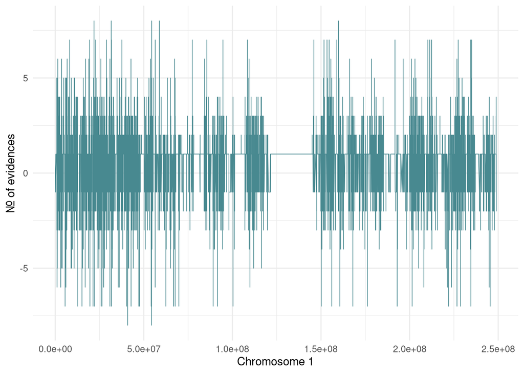

```r
EGR1_BS_cover %>%
  filter(Chromosome == "chr1") %>%
  ggplot(aes(x = Locus, y = Depth, group = Chromosome)) +
  geom_line(size = 0.3, color = "#488990") +
  xlab("Chromosome 1") +
  ylab("Nr. of evidences") +
  theme_minimal()
```

As you can see, there are no binding sites at the middle of the chromosome, where the centromere is located.

## 4.3 Plotting the number of evidences of binding sites on all chromosomes

Be avare that it may take a several minutes to render this plot and your computer even can run out of memory.

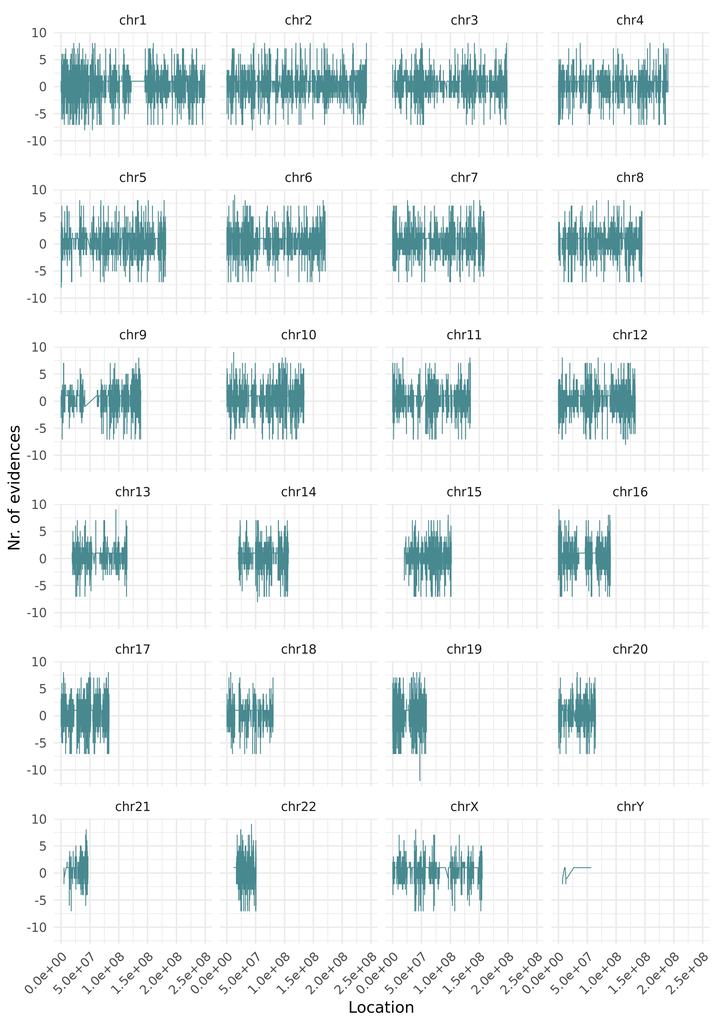

```r
p <- EGR1_BS_cover %>%
  ggplot(aes(x = Locus, y = Depth)) +
  geom_line(size = 0.3, color = "#488990") +
  xlab("Location") +
  ylab("Nr. of evidences")
p +
  facet_wrap(. ~ Chromosome, ncol = 4) +
  theme_minimal() +
  theme(axis.text.x = element_text(angle = 45, hjust=1))
```

# 5 How many EGR1 binding sites can be found on each chromosome?

Let’s use the downloaded *binding site table* again. We exclude non-canonical chromosomes.

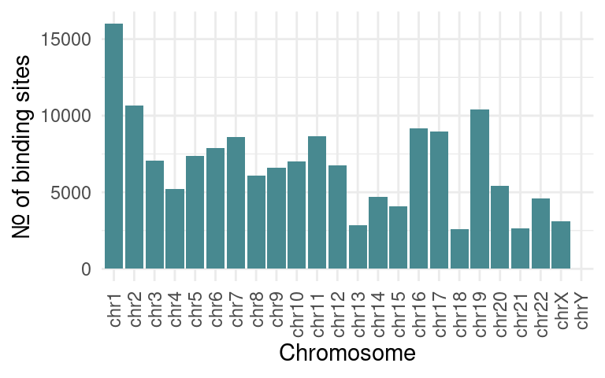

```r
# New variable with canonical chromosomes (as factor)
EGR1_BS_tab_canChro <- EGR1_BS_tab %>%
  filter(!grepl(x = Chromosome, pattern = "_|M")) %>%
  mutate(Chromosome = factor(Chromosome, levels = paste0("chr", c(1:22, "X", "Y"))))

# Barplot
EGR1_BS_tab_canChro %>%
  group_by(Chromosome) %>%
  summarise(n = n()) %>%
  ggplot(aes(x = Chromosome, y = n)) +
  geom_bar(stat="identity", fill = "#488990") +
  ylab("Nr. of binding sites") +
  theme_minimal() +
  theme(axis.text.x = element_text(angle = 90, vjust = 0.5, hjust=1))
```

*Chromosome 1* has the most binding site but what happens if we normalize the counts by the length of the chromosome (using the `chrom_sizes_tab` variable).

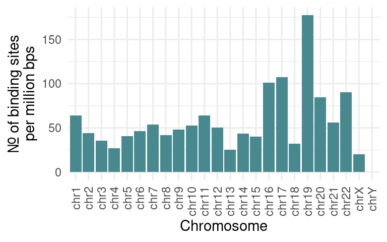

```r
# Normalization and barplotting
EGR1_BS_tab_canChro %>%
  group_by(Chromosome) %>%
  summarise(n = n()) %>%
  left_join(., chrom_sizes_tab) %>%
  mutate(Chromosome = factor(Chromosome,
                             levels = paste0("chr", c(1:22, "X", "Y")))) %>%
  mutate(`Nr. of binding sites\nper million bps` = n / (Size / 1000000)) %>%
  ggplot(aes(x = Chromosome, y = `Nr. of binding sites\nper million bps`)) +
  geom_bar(stat="identity", fill = "#488990") +
  theme_minimal() +
  theme(axis.text.x = element_text(angle = 90, vjust = 0.5, hjust=1))
```

Now we see that actually *chromosome 19* has the most binding sites of **ERG1**.

In the next chapter we check around which genes these binding sites are located.

# 6 Visually investigating the binding sites with the [IGV genome viewer](https://software.broadinstitute.org/software/igv/) software

Let’s do both!

First we need to index the **BAM** file using the samtools software.

```bash
$ samtools index EGR1_BS.bam
```

With the above command a new file, named `EGR1_BS.bam.bai` was created.

**After opening the IGV genome viewer:**

1. let’s set the human genome to *hg38* (open the drop down menu at the top left panel → `More`),
2. read the BAM file as “read” track (`File` → `Load from file...`),
3. color the “reads” by read strand (right click on the track in the left panel, `Color alignments by` → `read strand`),
4. group the “reads” by read strand (right click on the track in the left panel, `Group alignments by` → `read strand`),
5. read the downloaded GFF3 file as annotation track (`File` → `Load from file...`),
6. expand the annotation track (right click on the track in the left panel, `Expand`),
7. change the color of the annotation track to red (right click on the track in the left panel, `Change track color`),
8. zoom in to the region 137,188,319-137,189,579 on chromosome 9 (inserting `chr9:137,188,319-137,189,579` to the searching bar at top center, `Go`), and

we see the figure below.

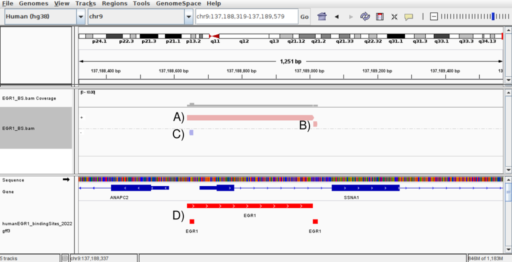

What we see at the “read” track area?

1. There is a longer (371bp) binding site on the forward strand (colored with light red) overlapping with the putative promoter region, the first exon and first intron, of gene **SSNA1**.
2. Also there is a shorter (13bp) binding site on the forward strand in the first intron of gene **SSNA1**.
3. There is a shorter (13bp) binding site on the reverse strand (colored with light blue) in the putative promoter region of gene **ANAPC2**.
4. At the “annotation” track area we see the similar picture but the orientation is showed by white arrows on the binding sites.

# 7 Environment